# Objective of the Project:

**To classify the patients into the respective labels using the attributes from their voice recordings**

#### Attribute Information:

1. **name** - ASCII subject name and recording number
2. **MDVP:Fo(Hz)** - Average vocal fundamental frequency
3. **MDVP:Fhi(Hz)** - Maximum vocal fundamental frequency
4. **MDVP:Flo(Hz)** - Minimum vocal fundamental frequency
5. **MDVP:Jitter(%)** - Measures of variation in fundamental frequency
6. **MDVP:Jitter(Abs)** - Measures of variation in fundamental frequency
7. **MDVP:RAP** - Measures of variation in fundamental frequency
8. **MDVP:PPQ** - Measures of variation in fundamental frequency
9. **Jitter:DDP** - Measures of variation in fundamental frequency
10. **MDVP:Shimmer** - Measures of variation in amplitude
11. **MDVP:Shimmer(dB)** - Measures of variation in amplitude
12. **Shimmer:APQ3** - Measures of variation in amplitude
13. **Shimmer:APQ5** - Measures of variation in amplitude
14. **MDVP:APQ** - Measures of variation in amplitude
15. **Shimmer:DDA** - Measures of variation in amplitude
16. **NHR** - Measures of ratio of noise to tonal components in the voice
17. **HNR** - Measures of ratio of noise to tonal components in the voice
18. **status** - Health status of the subject (one) - Parkinson's, (zero) - healthy
19. **RPDE** - Nonlinear dynamical complexity measures
20. **D2** - Nonlinear dynamical complexity measures
21. **DFA** - Signal fractal scaling exponent
22. **spread1** - Nonlinear measures of fundamental frequency
23. **spread2** - Nonlinear measures of fundamental frequency
24. **PPE** - Nonlinear measures of fundamental frequency

# Analyzing, understanding and describing each attribute

## Importing required libraries.

```python
import pandas as pd
import numpy as np
import pandas_profiling
import seaborn as sns
import matplotlib.pyplot as plt
%matplotlib inline
from sklearn.tree import DecisionTreeClassifier
from sklearn.ensemble import RandomForestClassifier
from sklearn.neighbors import KNeighborsClassifier
from sklearn.naive_bayes import GaussianNB
from sklearn.model_selection import cross_val_score
from sklearn.model_selection import train_test_split
from sklearn.metrics import accuracy_score, confusion_matrix
from sklearn import tree
from os import system
import os, sys
from IPython.display import Image
from sklearn import model_selection
from scipy.stats import zscore
from sklearn.metrics import classification_report, confusion_matrix
from sklearn.linear_model import LogisticRegression
from sklearn import svm
from sklearn.preprocessing import MinMaxScaler
from sklearn.preprocessing import StandardScaler
from sklearn import metrics
from sklearn import preprocessing
from sklearn.metrics import average_precision_score, confusion_matrix, accuracy_score, classification_report, plot_confusion_matrix
from mlxtend.classifier import StackingClassifier
from mlxtend.plotting import plot_decision_regions
import matplotlib.gridspec as gridspec
import itertools
```

#### Loading Dataset

```python
pds = pd.read_csv('Data - Parkinsons')
pds
```

|  | name | MDVP:Fo(Hz) | MDVP:Fhi(Hz) | MDVP:Flo(Hz) | MDVP:Jitter(%) | MDVP:Jitter(Abs) | MDVP:RAP | MDVP:PPQ | Jitter:DDP | MDVP:Shimmer | ... | Shimmer:DDA | NHR | HNR | status | RPDE | DFA | spread1 | spread2 | D2 | PPE |
| --- | --- | --- | --- | --- | --- | --- | --- | --- | --- | --- | --- | --- | --- | --- | --- | --- | --- | --- | --- | --- | --- |
| 0 | phon_R01_S01_1 | 119.992 | 157.302 | 74.997 | 0.00784 | 0.00007 | 0.00370 | 0.00554 | 0.01109 | 0.04374 | ... | 0.06545 | 0.02211 | 21.033 | 1 | 0.414783 | 0.815285 | -4.813031 | 0.266482 | 2.301442 | 0.284654 |
| 1 | phon_R01_S01_2 | 122.400 | 148.650 | 113.819 | 0.00968 | 0.00008 | 0.00465 | 0.00696 | 0.01394 | 0.06134 | ... | 0.09403 | 0.01929 | 19.085 | 1 | 0.458359 | 0.819521 | -4.075192 | 0.335590 | 2.486855 | 0.368674 |
| 2 | phon_R01_S01_3 | 116.682 | 131.111 | 111.555 | 0.01050 | 0.00009 | 0.00544 | 0.00781 | 0.01633 | 0.05233 | ... | 0.08270 | 0.01309 | 20.651 | 1 | 0.429895 | 0.825288 | -4.443179 | 0.311173 | 2.342259 | 0.332634 |
| 3 | phon_R01_S01_4 | 116.676 | 137.871 | 111.366 | 0.00997 | 0.00009 | 0.00502 | 0.00698 | 0.01505 | 0.05492 | ... | 0.08771 | 0.01353 | 20.644 | 1 | 0.434969 | 0.819235 | -4.117501 | 0.334147 | 2.405554 | 0.368975 |
| 4 | phon_R01_S01_5 | 116.014 | 141.781 | 110.655 | 0.01284 | 0.00011 | 0.00655 | 0.00908 | 0.01966 | 0.06425 | ... | 0.10470 | 0.01767 | 19.649 | 1 | 0.417356 | 0.823484 | -3.747787 | 0.234513 | 2.332180 | 0.410335 |
| ... | ... | ... | ... | ... | ... | ... | ... | ... | ... | ... | ... | ... | ... | ... | ... | ... | ... | ... | ... | ... | ... |
| 190 | phon_R01_S50_2 | 174.188 | 230.978 | 94.261 | 0.00459 | 0.00003 | 0.00263 | 0.00259 | 0.00790 | 0.04087 | ... | 0.07008 | 0.02764 | 19.517 | 0 | 0.448439 | 0.657899 | -6.538586 | 0.121952 | 2.657476 | 0.133050 |
| 191 | phon_R01_S50_3 | 209.516 | 253.017 | 89.488 | 0.00564 | 0.00003 | 0.00331 | 0.00292 | 0.00994 | 0.02751 | ... | 0.04812 | 0.01810 | 19.147 | 0 | 0.431674 | 0.683244 | -6.195325 | 0.129303 | 2.784312 | 0.168895 |
| 192 | phon_R01_S50_4 | 174.688 | 240.005 | 74.287 | 0.01360 | 0.00008 | 0.00624 | 0.00564 | 0.01873 | 0.02308 | ... | 0.03804 | 0.10715 | 17.883 | 0 | 0.407567 | 0.655683 | -6.787197 | 0.158453 | 2.679772 | 0.131728 |
| 193 | phon_R01_S50_5 | 198.764 | 396.961 | 74.904 | 0.00740 | 0.00004 | 0.00370 | 0.00390 | 0.01109 | 0.02296 | ... | 0.03794 | 0.07223 | 19.020 | 0 | 0.451221 | 0.643956 | -6.744577 | 0.207454 | 2.138608 | 0.123306 |
| 194 | phon_R01_S50_6 | 214.289 | 260.277 | 77.973 | 0.00567 | 0.00003 | 0.00295 | 0.00317 | 0.00885 | 0.01884 | ... | 0.03078 | 0.04398 | 21.209 | 0 | 0.462803 | 0.664357 | -5.724056 | 0.190667 | 2.555477 | 0.148569 |

195 rows × 24 columns

**Getting information of data set and any null values present**

```python
pds.info()
```

```
<class 'pandas.core.frame.DataFrame'>
RangeIndex: 195 entries, 0 to 194
Data columns (total 24 columns):
 #   Column            Non-Null Count  Dtype
---  ------            --------------  -----
 0   name              195 non-null    object
 1   MDVP:Fo(Hz)       195 non-null    float64
 2   MDVP:Fhi(Hz)      195 non-null    float64
 3   MDVP:Flo(Hz)      195 non-null    float64
 4   MDVP:Jitter(%)    195 non-null    float64
 5   MDVP:Jitter(Abs)  195 non-null    float64
 6   MDVP:RAP          195 non-null    float64
 7   MDVP:PPQ          195 non-null    float64
 8   Jitter:DDP        195 non-null    float64
 9   MDVP:Shimmer      195 non-null    float64
```

[output cut: 16 more lines]

#### 5 point summary defiened given as follows:

> 1. The minimum.
> 2. Q1 (the first quartile, or the 25% mark).
> 3. The median (50%).
> 4. Q3 (the third quartile, or the 75% mark).
> 5. The maximum.

```python
pds.describe()
```

|  | MDVP:Fo(Hz) | MDVP:Fhi(Hz) | MDVP:Flo(Hz) | MDVP:Jitter(%) | MDVP:Jitter(Abs) | MDVP:RAP | MDVP:PPQ | Jitter:DDP | MDVP:Shimmer | MDVP:Shimmer(dB) | ... | Shimmer:DDA | NHR | HNR | status | RPDE | DFA | spread1 | spread2 | D2 | PPE |
| --- | --- | --- | --- | --- | --- | --- | --- | --- | --- | --- | --- | --- | --- | --- | --- | --- | --- | --- | --- | --- | --- |
| count | 195.000000 | 195.000000 | 195.000000 | 195.000000 | 195.000000 | 195.000000 | 195.000000 | 195.000000 | 195.000000 | 195.000000 | ... | 195.000000 | 195.000000 | 195.000000 | 195.000000 | 195.000000 | 195.000000 | 195.000000 | 195.000000 | 195.000000 | 195.000000 |
| mean | 154.228641 | 197.104918 | 116.324631 | 0.006220 | 0.000044 | 0.003306 | 0.003446 | 0.009920 | 0.029709 | 0.282251 | ... | 0.046993 | 0.024847 | 21.885974 | 0.753846 | 0.498536 | 0.718099 | -5.684397 | 0.226510 | 2.381826 | 0.206552 |
| std | 41.390065 | 91.491548 | 43.521413 | 0.004848 | 0.000035 | 0.002968 | 0.002759 | 0.008903 | 0.018857 | 0.194877 | ... | 0.030459 | 0.040418 | 4.425764 | 0.431878 | 0.103942 | 0.055336 | 1.090208 | 0.083406 | 0.382799 | 0.090119 |
| min | 88.333000 | 102.145000 | 65.476000 | 0.001680 | 0.000007 | 0.000680 | 0.000920 | 0.002040 | 0.009540 | 0.085000 | ... | 0.013640 | 0.000650 | 8.441000 | 0.000000 | 0.256570 | 0.574282 | -7.964984 | 0.006274 | 1.423287 | 0.044539 |
| 25% | 117.572000 | 134.862500 | 84.291000 | 0.003460 | 0.000020 | 0.001660 | 0.001860 | 0.004985 | 0.016505 | 0.148500 | ... | 0.024735 | 0.005925 | 19.198000 | 1.000000 | 0.421306 | 0.674758 | -6.450096 | 0.174351 | 2.099125 | 0.137451 |
| 50% | 148.790000 | 175.829000 | 104.315000 | 0.004940 | 0.000030 | 0.002500 | 0.002690 | 0.007490 | 0.022970 | 0.221000 | ... | 0.038360 | 0.011660 | 22.085000 | 1.000000 | 0.495954 | 0.722254 | -5.720868 | 0.218885 | 2.361532 | 0.194052 |
| 75% | 182.769000 | 224.205500 | 140.018500 | 0.007365 | 0.000060 | 0.003835 | 0.003955 | 0.011505 | 0.037885 | 0.350000 | ... | 0.060795 | 0.025640 | 25.075500 | 1.000000 | 0.587562 | 0.761881 | -5.046192 | 0.279234 | 2.636456 | 0.252980 |
| max | 260.105000 | 592.030000 | 239.170000 | 0.033160 | 0.000260 | 0.021440 | 0.019580 | 0.064330 | 0.119080 | 1.302000 | ... | 0.169420 | 0.314820 | 33.047000 | 1.000000 | 0.685151 | 0.825288 | -2.434031 | 0.450493 | 3.671155 | 0.527367 |

8 rows × 23 columns

```python
#Moving status column to the last
df1=pds.pop('status')
pds['status'] = df1
```

```python
pds.head()
```

|  | name | MDVP:Fo(Hz) | MDVP:Fhi(Hz) | MDVP:Flo(Hz) | MDVP:Jitter(%) | MDVP:Jitter(Abs) | MDVP:RAP | MDVP:PPQ | Jitter:DDP | MDVP:Shimmer | ... | Shimmer:DDA | NHR | HNR | RPDE | DFA | spread1 | spread2 | D2 | PPE | status |
| --- | --- | --- | --- | --- | --- | --- | --- | --- | --- | --- | --- | --- | --- | --- | --- | --- | --- | --- | --- | --- | --- |
| 0 | phon_R01_S01_1 | 119.992 | 157.302 | 74.997 | 0.00784 | 0.00007 | 0.00370 | 0.00554 | 0.01109 | 0.04374 | ... | 0.06545 | 0.02211 | 21.033 | 0.414783 | 0.815285 | -4.813031 | 0.266482 | 2.301442 | 0.284654 | 1 |
| 1 | phon_R01_S01_2 | 122.400 | 148.650 | 113.819 | 0.00968 | 0.00008 | 0.00465 | 0.00696 | 0.01394 | 0.06134 | ... | 0.09403 | 0.01929 | 19.085 | 0.458359 | 0.819521 | -4.075192 | 0.335590 | 2.486855 | 0.368674 | 1 |
| 2 | phon_R01_S01_3 | 116.682 | 131.111 | 111.555 | 0.01050 | 0.00009 | 0.00544 | 0.00781 | 0.01633 | 0.05233 | ... | 0.08270 | 0.01309 | 20.651 | 0.429895 | 0.825288 | -4.443179 | 0.311173 | 2.342259 | 0.332634 | 1 |
| 3 | phon_R01_S01_4 | 116.676 | 137.871 | 111.366 | 0.00997 | 0.00009 | 0.00502 | 0.00698 | 0.01505 | 0.05492 | ... | 0.08771 | 0.01353 | 20.644 | 0.434969 | 0.819235 | -4.117501 | 0.334147 | 2.405554 | 0.368975 | 1 |
| 4 | phon_R01_S01_5 | 116.014 | 141.781 | 110.655 | 0.01284 | 0.00011 | 0.00655 | 0.00908 | 0.01966 | 0.06425 | ... | 0.10470 | 0.01767 | 19.649 | 0.417356 | 0.823484 | -3.747787 | 0.234513 | 2.332180 | 0.410335 | 1 |

5 rows × 24 columns

Getting following requirement of data:-

1. terms of number of records
2. structure of the file
3. number of attributes
4. types of attributes
5. general idea of likely challenges in the dataset.

```python
print('1. The total record contains',pds.shape[0]*pds.shape[1],'data.')
```

```
1. The total record contains 4680 data.
```

```python
print('2. The data contains \n   row = ',pds.shape[0],'\n   col = ',pds.shape[1])
```

```
2. The data contains
   row =  195
   col =  24
```

```python
print('3. Attirbutes Names:')
list(pds.columns)
```

```
3. Attirbutes Names:
```

```
['name',
 'MDVP:Fo(Hz)',
 'MDVP:Fhi(Hz)',
 'MDVP:Flo(Hz)',
 'MDVP:Jitter(%)',
 'MDVP:Jitter(Abs)',
 'MDVP:RAP',
 'MDVP:PPQ',
 'Jitter:DDP',
 'MDVP:Shimmer',
 'MDVP:Shimmer(dB)',
 'Shimmer:APQ3',
 'Shimmer:APQ5',
 'MDVP:APQ',
 'Shimmer:DDA',
 'NHR',
 'HNR',
 'RPDE',
 'DFA',
 'spread1',
 'spread2',
 'D2',
 'PPE',
 'status']
```

```python
print('4. Types of attributes:')
print('''\n\033[1m''' + '''> Categorical Feature:''' + '''\033[0m''')
print('''- Name
- Status''')


print('''\n\033[1m''' + '''> Numerical feature:''' + '''\033[0m''')
print('''- MDVP:Fo(Hz)
- MDVP:Fhi(Hz)
- MDVP:Flo(Hz)
- MDVP:Jitter(%)
- MDVP:Jitter(Abs)
- MDVP:RAP
- MDVP:PPQ
- Jitter:DDP
- MDVP:Shimmer
- MDVP:Shimmer(dB)
- Shimmer:APQ3
- Shimmer:APQ5
- MDVP:APQ
- Shimmer:DDA
- NHR
- HNR
- RPDE
- DFA
- spread1
- spread2
- D2
- PPE
''')
```

```
4. Types of attributes:

> Categorical Feature:
- Name
- Status

> Numerical feature:
- MDVP:Fo(Hz)
- MDVP:Fhi(Hz)
- MDVP:Flo(Hz)
- MDVP:Jitter(%)
- MDVP:Jitter(Abs)
- MDVP:RAP
- MDVP:PPQ
- Jitter:DDP
- MDVP:Shimmer
- MDVP:Shimmer(dB)
- Shimmer:APQ3
- Shimmer:APQ5
- MDVP:APQ
- Shimmer:DDA
- NHR
- HNR
- RPDE
- DFA
- spread1
- spread2
- D2
- PPE
```

```python
pds1 = pds.drop('name',axis=1)
```

```python
pdt=pds1

for x in pdt:
    pds[x]=pds[x].astype(float)
    att = pds[x]
    #main
    a = att.lt(0).sum()
    outlier = []
    outliervalue = []
    if a != 0:
        print(x,'has Negative Value of',a)
```

```
spread1 has Negative Value of 195
```

## Checking the presence of outliers in columns

```python
for x in pds1:
    pds1[x]=pds1[x].astype(float)
    att = pds1[x]
    mean = np.mean(att)
    std = np.std(att)
    #print('\nmean of',x,' the dataset is', mean)
   # print('\nstd. deviation of',x,' is', std)
    outlier = []
    outliervalue = []
    for i in att:
        z = (i-mean)/std
        if z < -3.00 or z > 3.00:
            outlier.append(i)
            outliervalue.append(z)
    print('No. of outlier of',x,'in dataset is',len(outlier))
```

```
No. of outlier of MDVP:Fo(Hz) in dataset is 0
No. of outlier of MDVP:Fhi(Hz) in dataset is 7
No. of outlier of MDVP:Flo(Hz) in dataset is 0
No. of outlier of MDVP:Jitter(%) in dataset is 4
No. of outlier of MDVP:Jitter(Abs) in dataset is 5
No. of outlier of MDVP:RAP in dataset is 4
No. of outlier of MDVP:PPQ in dataset is 4
No. of outlier of Jitter:DDP in dataset is 4
No. of outlier of MDVP:Shimmer in dataset is 4
No. of outlier of MDVP:Shimmer(dB) in dataset is 4
No. of outlier of Shimmer:APQ3 in dataset is 3
No. of outlier of Shimmer:APQ5 in dataset is 3
No. of outlier of MDVP:APQ in dataset is 3
No. of outlier of Shimmer:DDA in dataset is 3
No. of outlier of NHR in dataset is 5
No. of outlier of HNR in dataset is 1
No. of outlier of RPDE in dataset is 0
No. of outlier of DFA in dataset is 0
No. of outlier of spread1 in dataset is 0
No. of outlier of spread2 in dataset is 0
No. of outlier of D2 in dataset is 1
No. of outlier of PPE in dataset is 1
No. of outlier of status in dataset is 0
```

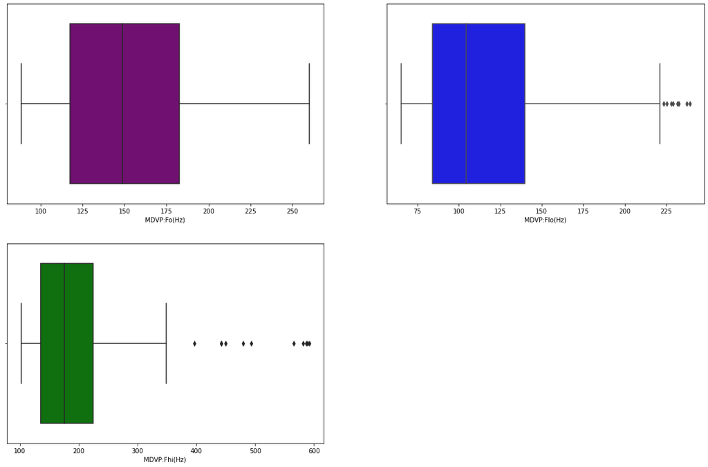

```python
plt.figure(figsize= (20,20))

plt.subplot(3,2,1)
sns.boxplot(x= pds['MDVP:Fo(Hz)'], color='purple')
plt.xlabel('MDVP:Fo(Hz)')

plt.subplot(3,2,2)
sns.boxplot(x= pds['MDVP:Flo(Hz)'], color='blue')
plt.xlabel('MDVP:Flo(Hz)')

plt.subplot(3,2,3)
sns.boxplot(x= pds['MDVP:Fhi(Hz)'], color='green')
plt.xlabel('MDVP:Fhi(Hz)')
plt.show()
```

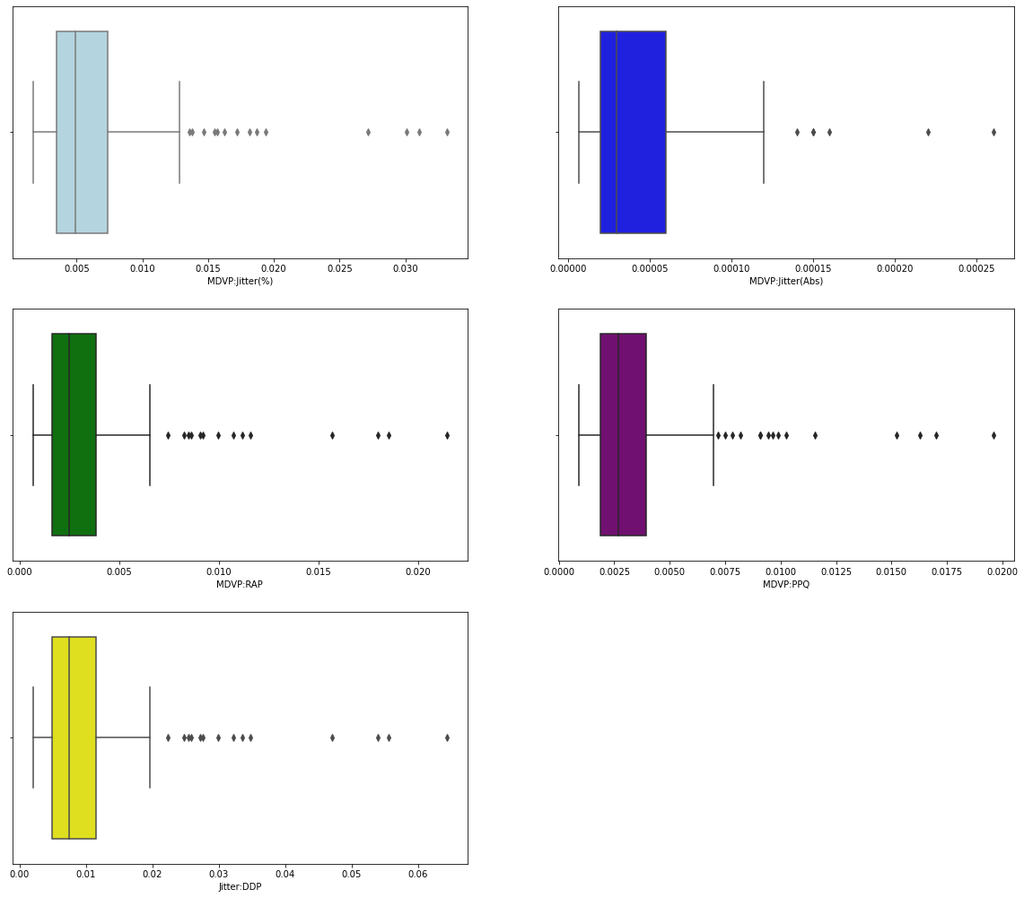

```python
plt.figure(figsize= (20,30))

plt.subplot(5,2,1)
sns.boxplot(x= pds['MDVP:Jitter(%)'], color='lightblue')
plt.xlabel('MDVP:Jitter(%)')

plt.subplot(5,2,2)
sns.boxplot(x= pds['MDVP:Jitter(Abs)'], color='blue')
plt.xlabel('MDVP:Jitter(Abs)')

plt.subplot(5,2,3)
sns.boxplot(x= pds['MDVP:RAP'], color='green')
plt.xlabel('MDVP:RAP')

plt.subplot(5,2,4)
sns.boxplot(x= pds['MDVP:PPQ'], color='purple')
plt.xlabel('MDVP:PPQ')

plt.subplot(5,2,5)
sns.boxplot(x= pds['Jitter:DDP'], color='yellow')
plt.xlabel('Jitter:DDP')

plt.show()
```

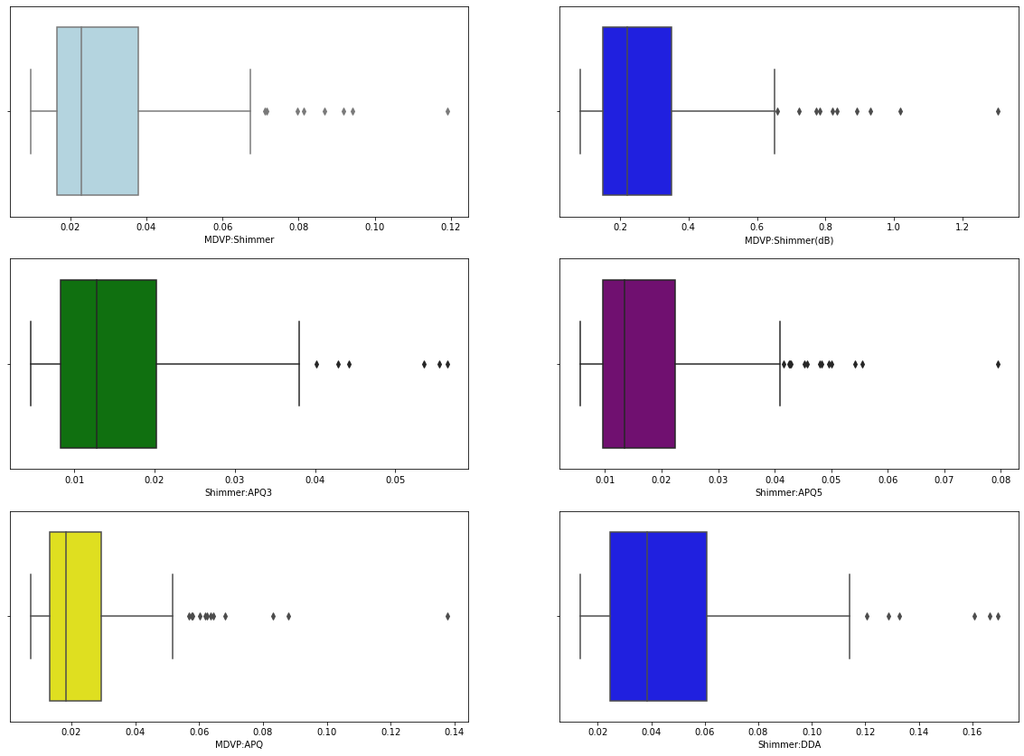

```python
plt.figure(figsize= (20,30))

plt.subplot(6,2,1)
sns.boxplot(x= pds['MDVP:Shimmer'], color='lightblue')
plt.xlabel('MDVP:Shimmer')

plt.subplot(6,2,2)
sns.boxplot(x= pds['MDVP:Shimmer(dB)'], color='blue')
plt.xlabel('MDVP:Shimmer(dB)')

plt.subplot(6,2,3)
sns.boxplot(x= pds['Shimmer:APQ3'], color='green')
plt.xlabel('Shimmer:APQ3')

plt.subplot(6,2,4)
sns.boxplot(x= pds['Shimmer:APQ5'], color='purple')
plt.xlabel('Shimmer:APQ5')

plt.subplot(6,2,5)
sns.boxplot(x= pds['MDVP:APQ'], color='yellow')
plt.xlabel('MDVP:APQ')

plt.subplot(6,2,6)
sns.boxplot(x= pds['Shimmer:DDA'], color='blue')
plt.xlabel('Shimmer:DDA')


plt.show()
```

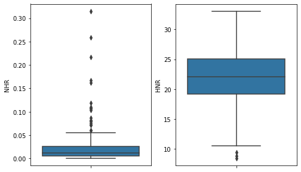

```python
fig, ax = plt.subplots(1,2,figsize=(8,5))
sns.boxplot(x='NHR',data=pds, ax=ax[0],orient='v')
sns.boxplot(x='HNR',data=pds, ax=ax[1],orient='v')
```

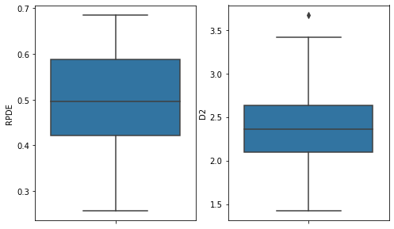

```python
fig, ax = plt.subplots(1,2,figsize=(8,5))
sns.boxplot(x='RPDE',data=pds, ax=ax[0],orient='v')
sns.boxplot(x='D2',data=pds, ax=ax[1],orient='v')
```

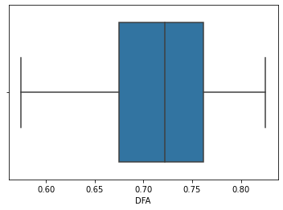

```python
sns.boxplot(x='DFA',data=pds)
```

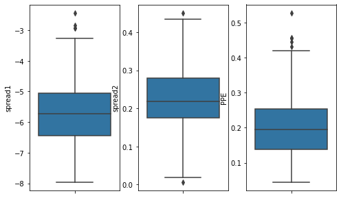

```python
fig, ax = plt.subplots(1,3,figsize=(8,5))
sns.boxplot(x='spread1',data=pds, ax=ax[0],orient='v')
sns.boxplot(x='spread2',data=pds, ax=ax[1],orient='v')
sns.boxplot(x='PPE',data=pds,ax=ax[2],orient='v')
```

## Correlation comparision

```python
a = pds1.corr()
a
```

|  | MDVP:Fo(Hz) | MDVP:Fhi(Hz) | MDVP:Flo(Hz) | MDVP:Jitter(%) | MDVP:Jitter(Abs) | MDVP:RAP | MDVP:PPQ | Jitter:DDP | MDVP:Shimmer | MDVP:Shimmer(dB) | ... | Shimmer:DDA | NHR | HNR | RPDE | DFA | spread1 | spread2 | D2 | PPE | status |
| --- | --- | --- | --- | --- | --- | --- | --- | --- | --- | --- | --- | --- | --- | --- | --- | --- | --- | --- | --- | --- | --- |
| MDVP:Fo(Hz) | 1.000000 | 0.400985 | 0.596546 | -0.118003 | -0.382027 | -0.076194 | -0.112165 | -0.076213 | -0.098374 | -0.073742 | ... | -0.094732 | -0.021981 | 0.059144 | -0.383894 | -0.446013 | -0.413738 | -0.249450 | 0.177980 | -0.372356 | -0.383535 |
| MDVP:Fhi(Hz) | 0.400985 | 1.000000 | 0.084951 | 0.102086 | -0.029198 | 0.097177 | 0.091126 | 0.097150 | 0.002281 | 0.043465 | ... | -0.003733 | 0.163766 | -0.024893 | -0.112404 | -0.343097 | -0.076658 | -0.002954 | 0.176323 | -0.069543 | -0.166136 |
| MDVP:Flo(Hz) | 0.596546 | 0.084951 | 1.000000 | -0.139919 | -0.277815 | -0.100519 | -0.095828 | -0.100488 | -0.144543 | -0.119089 | ... | -0.150737 | -0.108670 | 0.210851 | -0.400143 | -0.050406 | -0.394857 | -0.243829 | -0.100629 | -0.340071 | -0.380200 |
| MDVP:Jitter(%) | -0.118003 | 0.102086 | -0.139919 | 1.000000 | 0.935714 | 0.990276 | 0.974256 | 0.990276 | 0.769063 | 0.804289 | ... | 0.746635 | 0.906959 | -0.728165 | 0.360673 | 0.098572 | 0.693577 | 0.385123 | 0.433434 | 0.721543 | 0.278220 |
| MDVP:Jitter(Abs) | -0.382027 | -0.029198 | -0.277815 | 0.935714 | 1.000000 | 0.922911 | 0.897778 | 0.922913 | 0.703322 | 0.716601 | ... | 0.697170 | 0.834972 | -0.656810 | 0.441839 | 0.175036 | 0.735779 | 0.388543 | 0.310694 | 0.748162 | 0.338653 |
| MDVP:RAP | -0.076194 | 0.097177 | -0.100519 | 0.990276 | 0.922911 | 1.000000 | 0.957317 | 1.000000 | 0.759581 | 0.790652 | ... | 0.744919 | 0.919521 | -0.721543 | 0.342140 | 0.064083 | 0.648328 | 0.324407 | 0.426605 | 0.670999 | 0.266668 |
| MDVP:PPQ | -0.112165 | 0.091126 | -0.095828 | 0.974256 | 0.897778 | 0.957317 | 1.000000 | 0.957319 | 0.797826 | 0.839239 | ... | 0.763592 | 0.844604 | -0.731510 | 0.333274 | 0.196301 | 0.716489 | 0.407605 | 0.412524 | 0.769647 | 0.288698 |
| Jitter:DDP | -0.076213 | 0.097150 | -0.100488 | 0.990276 | 0.922913 | 1.000000 | 0.957319 | 1.000000 | 0.759555 | 0.790621 | ... | 0.744901 | 0.919548 | -0.721494 | 0.342079 | 0.064026 | 0.648328 | 0.324377 | 0.426556 | 0.671005 | 0.266646 |
| MDVP:Shimmer | -0.098374 | 0.002281 | -0.144543 | 0.769063 | 0.703322 | 0.759581 | 0.797826 | 0.759555 | 1.000000 | 0.987258 | ... | 0.987626 | 0.722194 | -0.835271 | 0.447424 | 0.159954 | 0.654734 | 0.452025 | 0.507088 | 0.693771 | 0.367430 |
| MDVP:Shimmer(dB) | -0.073742 | 0.043465 | -0.119089 | 0.804289 | 0.716601 | 0.790652 | 0.839239 | 0.790621 | 0.987258 | 1.000000 | ... | 0.963202 | 0.744477 | -0.827805 | 0.410684 | 0.165157 | 0.652547 | 0.454314 | 0.512233 | 0.695058 | 0.350697 |
| Shimmer:APQ3 | -0.094717 | -0.003743 | -0.150747 | 0.746625 | 0.697153 | 0.744912 | 0.763580 | 0.744894 | 0.987625 | 0.963198 | ... | 1.000000 | 0.716207 | -0.827123 | 0.435242 | 0.151124 | 0.610967 | 0.402243 | 0.467265 | 0.645377 | 0.347617 |
| Shimmer:APQ5 | -0.070682 | -0.009997 | -0.101095 | 0.725561 | 0.648961 | 0.709927 | 0.786780 | 0.709907 | 0.982835 | 0.973751 | ... | 0.960072 | 0.658080 | -0.813753 | 0.399903 | 0.213873 | 0.646809 | 0.457195 | 0.502174 | 0.702456 | 0.351148 |
| MDVP:APQ | -0.077774 | 0.004937 | -0.107293 | 0.758255 | 0.648793 | 0.737455 | 0.804139 | 0.737439 | 0.950083 | 0.960977 | ... | 0.896647 | 0.694019 | -0.800407 | 0.451379 | 0.157276 | 0.673158 | 0.502188 | 0.536869 | 0.721694 | 0.364316 |
| Shimmer:DDA | -0.094732 | -0.003733 | -0.150737 | 0.746635 | 0.697170 | 0.744919 | 0.763592 | 0.744901 | 0.987626 | 0.963202 | ... | 1.000000 | 0.716215 | -0.827130 | 0.435237 | 0.151132 | 0.610971 | 0.402223 | 0.467261 | 0.645389 | 0.347608 |
| NHR | -0.021981 | 0.163766 | -0.108670 | 0.906959 | 0.834972 | 0.919521 | 0.844604 | 0.919548 | 0.722194 | 0.744477 | ... | 0.716215 | 1.000000 | -0.714072 | 0.370890 | -0.131882 | 0.540865 | 0.318099 | 0.470949 | 0.552591 | 0.189429 |
| HNR | 0.059144 | -0.024893 | 0.210851 | -0.728165 | -0.656810 | -0.721543 | -0.731510 | -0.721494 | -0.835271 | -0.827805 | ... | -0.827130 | -0.714072 | 1.000000 | -0.598736 | -0.008665 | -0.673210 | -0.431564 | -0.601401 | -0.692876 | -0.361515 |
| RPDE | -0.383894 | -0.112404 | -0.400143 | 0.360673 | 0.441839 | 0.342140 | 0.333274 | 0.342079 | 0.447424 | 0.410684 | ... | 0.435237 | 0.370890 | -0.598736 | 1.000000 | -0.110950 | 0.591117 | 0.479905 | 0.236931 | 0.545886 | 0.308567 |
| DFA | -0.446013 | -0.343097 | -0.050406 | 0.098572 | 0.175036 | 0.064083 | 0.196301 | 0.064026 | 0.159954 | 0.165157 | ... | 0.151132 | -0.131882 | -0.008665 | -0.110950 | 1.000000 | 0.195668 | 0.166548 | -0.165381 | 0.270445 | 0.231739 |
| spread1 | -0.413738 | -0.076658 | -0.394857 | 0.693577 | 0.735779 | 0.648328 | 0.716489 | 0.648328 | 0.654734 | 0.652547 | ... | 0.610971 | 0.540865 | -0.673210 | 0.591117 | 0.195668 | 1.000000 | 0.652358 | 0.495123 | 0.962435 | 0.564838 |
| spread2 | -0.249450 | -0.002954 | -0.243829 | 0.385123 | 0.388543 | 0.324407 | 0.407605 | 0.324377 | 0.452025 | 0.454314 | ... | 0.402223 | 0.318099 | -0.431564 | 0.479905 | 0.166548 | 0.652358 | 1.000000 | 0.523532 | 0.644711 | 0.454842 |
| D2 | 0.177980 | 0.176323 | -0.100629 | 0.433434 | 0.310694 | 0.426605 | 0.412524 | 0.426556 | 0.507088 | 0.512233 | ... | 0.467261 | 0.470949 | -0.601401 | 0.236931 | -0.165381 | 0.495123 | 0.523532 | 1.000000 | 0.480585 | 0.340232 |
| PPE | -0.372356 | -0.069543 | -0.340071 | 0.721543 | 0.748162 | 0.670999 | 0.769647 | 0.671005 | 0.693771 | 0.695058 | ... | 0.645389 | 0.552591 | -0.692876 | 0.545886 | 0.270445 | 0.962435 | 0.644711 | 0.480585 | 1.000000 | 0.531039 |
| status | -0.383535 | -0.166136 | -0.380200 | 0.278220 | 0.338653 | 0.266668 | 0.288698 | 0.266646 | 0.367430 | 0.350697 | ... | 0.347608 | 0.189429 | -0.361515 | 0.308567 | 0.231739 | 0.564838 | 0.454842 | 0.340232 | 0.531039 | 1.000000 |

23 rows × 23 columns

**Getting maximm positive and negative correlations of attributes**

```python
for i in a:
    v=a[i]
    outlier1 = []
    index1=[]
    for x in v:
        if x >= .5 and x != 1.0:
            n=list(v[v==x].index)
            index1.append(n)
            outlier1.append(x)
            cpr = pd.DataFrame(list(zip(index1, outlier1)))
    print('Max Positive Correlation of',i,'with\n',cpr.to_string(index = False,columns=None),'\n')
```

```
Max Positive Correlation of MDVP:Fo(Hz) with
               0         1
 [MDVP:Flo(Hz)]  0.596546

Max Positive Correlation of MDVP:Fhi(Hz) with
               0         1
 [MDVP:Flo(Hz)]  0.596546

Max Positive Correlation of MDVP:Flo(Hz) with
              0         1
 [MDVP:Fo(Hz)]  0.596546

Max Positive Correlation of MDVP:Jitter(%) with
                   0         1
 [MDVP:Jitter(Abs)]  0.935714
         [MDVP:RAP]  0.990276
         [MDVP:PPQ]  0.974256
       [Jitter:DDP]  0.990276
     [MDVP:Shimmer]  0.769063
 [MDVP:Shimmer(dB)]  0.804289
     [Shimmer:APQ3]  0.746625
     [Shimmer:APQ5]  0.725561
         [MDVP:APQ]  0.758255
      [Shimmer:DDA]  0.746635
              [NHR]  0.906959
          [spread1]  0.693577
              [PPE]  0.721543

Max Positive Correlation of MDVP:Jitter(Abs) with
                   0         1
   [MDVP:Jitter(%)]  0.935714
         [MDVP:RAP]  0.922911
         [MDVP:PPQ]  0.897778
       [Jitter:DDP]  0.922913
     [MDVP:Shimmer]  0.703322
 [MDVP:Shimmer(dB)]  0.716601
     [Shimmer:APQ3]  0.697153
     [Shimmer:APQ5]  0.648961
         [MDVP:APQ]  0.648793
      [Shimmer:DDA]  0.697170
```

[output cut: 237 more lines]

```
 [MDVP:Shimmer(dB)]  0.695058
     [Shimmer:APQ3]  0.645377
     [Shimmer:APQ5]  0.702456
         [MDVP:APQ]  0.721694
      [Shimmer:DDA]  0.645389
              [NHR]  0.552591
             [RPDE]  0.545886
          [spread1]  0.962435
          [spread2]  0.644711
           [status]  0.531039

Max Positive Correlation of status with
          0         1
 [spread1]  0.564838
     [PPE]  0.531039
```

**SHOWS ATTRIBUTES HAVE POSITIVE RELATIONSHIP BETWEEN THEM**

```python
for i in a:
    v=a[i]
    outlier2 = []
    index2=[]
    for x in v:
        if x <= -.5:
            n=list(v[v==x].index)
            index2.append(n)
            outlier2.append(x)
            cnr = pd.DataFrame(list(zip(index2, outlier2)))
    print('Max Negative Correlation of',i,'with\n',cnr.to_string(index = False,columns=None),'\n')
```

```
Max Negative Correlation of MDVP:Fo(Hz) with
      0         1
 [HNR] -0.692876

Max Negative Correlation of MDVP:Fhi(Hz) with
      0         1
 [HNR] -0.692876

Max Negative Correlation of MDVP:Flo(Hz) with
      0         1
 [HNR] -0.692876

Max Negative Correlation of MDVP:Jitter(%) with
      0         1
 [HNR] -0.728165

Max Negative Correlation of MDVP:Jitter(Abs) with
      0        1
 [HNR] -0.65681

Max Negative Correlation of MDVP:RAP with
      0         1
 [HNR] -0.721543

Max Negative Correlation of MDVP:PPQ with
      0        1
 [HNR] -0.73151

Max Negative Correlation of Jitter:DDP with
      0         1
 [HNR] -0.721494

Max Negative Correlation of MDVP:Shimmer with
      0         1
 [HNR] -0.835271

Max Negative Correlation of MDVP:Shimmer(dB) with
      0         1
 [HNR] -0.827805

```

[output cut: 51 more lines]

```
Max Negative Correlation of spread2 with
      0        1
 [HNR] -0.67321

Max Negative Correlation of D2 with
      0         1
 [HNR] -0.601401

Max Negative Correlation of PPE with
      0         1
 [HNR] -0.692876

Max Negative Correlation of status with
      0         1
 [HNR] -0.692876
```

**SHOWS ATTRIBUTES HAVE NEGATIVE RELATIONSHIP BETWEEN THEM**

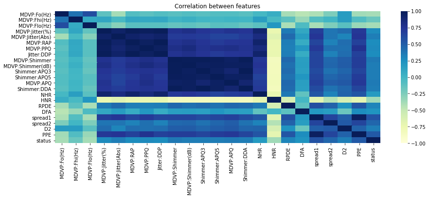

```python
corr = pds1.corr()
plt.figure(figsize=(15, 5))

sns.heatmap(corr, cmap='YlGnBu', vmax=1.0, vmin=-1.0)

plt.title('Correlation between features')
plt.show()
```

# Univariate Analysis

```
MDVP:Fo(Hz) is Positively Skewed towards Right side of asymmetric distribution as Skewness = 0.592
```

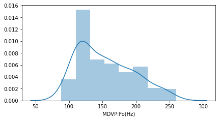

```
MDVP:Flo(Hz) is Positively Skewed towards Right side of asymmetric distribution as Skewness = 1.217
```

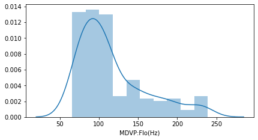

```
MDVP:Fhi(Hz) is Positively Skewed towards Right side of asymmetric distribution as Skewness = 2.542
```

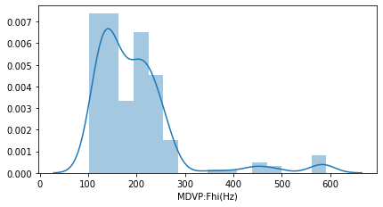

```python
n=1
pds2=pds[['MDVP:Fo(Hz)','MDVP:Flo(Hz)','MDVP:Fhi(Hz)']]
for x in pds2:
    series          = pds2[x]
    skewness        = series.skew()
    if skewness > -.5  and skewness < .5 :
        print(x,"is Symmetrically Skewed as Skewness =",round(skewness,3),'\n')
    elif skewness > .25:
            print(x,"is Positively Skewed towards Right side of asymmetric distribution as Skewness =",round(skewness,3),'\n')
    elif skewness < -.25:
            print(x,"is Negatively Skewed towards Left side of asymmetric distribution as Skewness =",round(skewness,3),'\n')
    plt.figure(figsize= (15,20))
    plt.subplot(5,2,n)
    n=n+1
    sns.distplot(pds2[x])
    plt.xlabel(x)
    plt.show()
```

```
MDVP:Jitter(%) is Positively Skewed towards Right side of asymmetric distribution as Skewness = 3.085
```

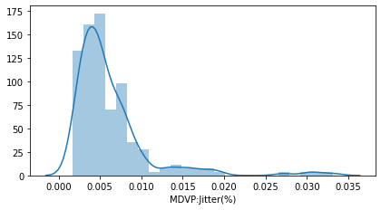

```
MDVP:Jitter(Abs) is Positively Skewed towards Right side of asymmetric distribution as Skewness = 2.649
```

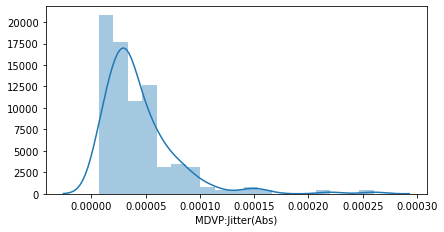

```
MDVP:RAP is Positively Skewed towards Right side of asymmetric distribution as Skewness = 3.361
```

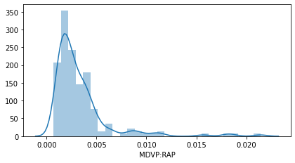

```
MDVP:PPQ is Positively Skewed towards Right side of asymmetric distribution as Skewness = 3.074
```

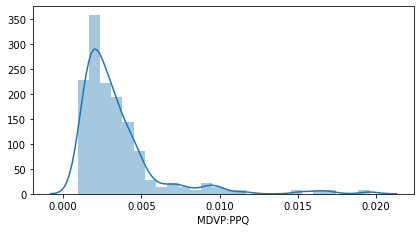

```
Jitter:DDP is Positively Skewed towards Right side of asymmetric distribution as Skewness = 3.362
```

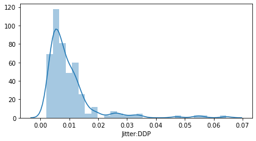

```python
n=1
pds2=pds[['MDVP:Jitter(%)','MDVP:Jitter(Abs)','MDVP:RAP','MDVP:PPQ','Jitter:DDP']]
for x in pds2:
    series          = pds2[x]
    skewness        = series.skew()
    if skewness > -.5  and skewness < .5 :
        print(x,"is Symmetrically Skewed as Skewness =",round(skewness,3),'\n')
    elif skewness > .25:
            print(x,"is Positively Skewed towards Right side of asymmetric distribution as Skewness =",round(skewness,3),'\n')
    elif skewness < -.25:
            print(x,"is Negatively Skewed towards Left side of asymmetric distribution as Skewness =",round(skewness,3),'\n')
    plt.figure(figsize= (15,20))
    plt.subplot(5,2,n)
    n=n+1
    sns.distplot(pds2[x])
    plt.xlabel(x)
    plt.show()
```

```
MDVP:Shimmer is Positively Skewed towards Right side of asymmetric distribution as Skewness = 1.666
```

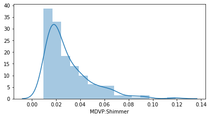

```
MDVP:Shimmer(dB) is Positively Skewed towards Right side of asymmetric distribution as Skewness = 1.999
```

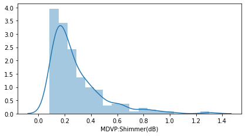

```
Shimmer:APQ3 is Positively Skewed towards Right side of asymmetric distribution as Skewness = 1.581
```

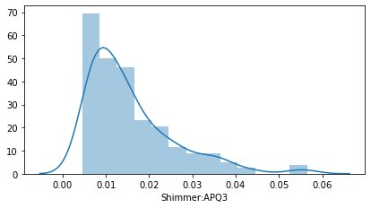

```
Shimmer:APQ5 is Positively Skewed towards Right side of asymmetric distribution as Skewness = 1.799
```

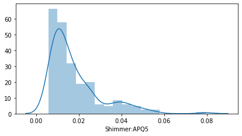

```
MDVP:APQ is Positively Skewed towards Right side of asymmetric distribution as Skewness = 2.618
```

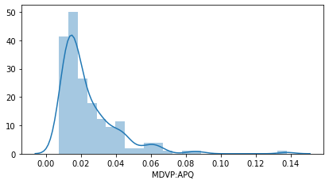

```
Shimmer:DDA is Positively Skewed towards Right side of asymmetric distribution as Skewness = 1.581
```

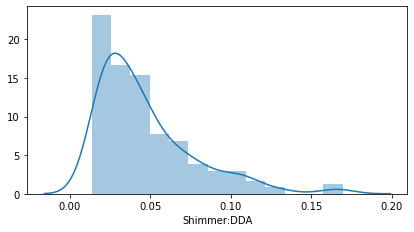

```python
n=1
pds2=pds[['MDVP:Shimmer','MDVP:Shimmer(dB)','Shimmer:APQ3','Shimmer:APQ5','MDVP:APQ','Shimmer:DDA']]
for x in pds2:
    series          = pds2[x]
    skewness        = series.skew()
    if skewness > -.5  and skewness < .5 :
        print(x,"is Symmetrically Skewed as Skewness =",round(skewness,3),'\n')
    elif skewness > .25:
            print(x,"is Positively Skewed towards Right side of asymmetric distribution as Skewness =",round(skewness,3),'\n')
    elif skewness < -.25:
            print(x,"is Negatively Skewed towards Left side of asymmetric distribution as Skewness =",round(skewness,3),'\n')
    plt.figure(figsize= (15,20))
    plt.subplot(5,2,n)
    n=n+1
    sns.distplot(pds2[x])
    plt.xlabel(x)
    plt.show()
```

```
HNR is Negatively Skewed towards Left side of asymmetric distribution as Skewness = -0.514
```

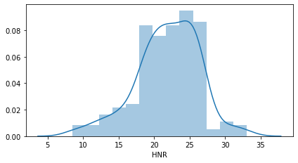

```
NHR is Positively Skewed towards Right side of asymmetric distribution as Skewness = 4.221
```

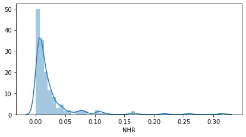

```python
n=1
pds2=pds[['HNR','NHR']]
for x in pds2:
    series          = pds2[x]
    skewness        = series.skew()
    if skewness > -.5  and skewness < .5 :
        print(x,"is Symmetrically Skewed as Skewness =",round(skewness,3),'\n')
    elif skewness > .25:
            print(x,"is Positively Skewed towards Right side of asymmetric distribution as Skewness =",round(skewness,3),'\n')
    elif skewness < -.25:
            print(x,"is Negatively Skewed towards Left side of asymmetric distribution as Skewness =",round(skewness,3),'\n')
    plt.figure(figsize= (15,20))
    plt.subplot(5,2,n)
    n=n+1
    sns.distplot(pds2[x])
    plt.xlabel(x)
    plt.show()
```

```
RPDE is Symmetrically Skewed as Skewness = -0.143
```

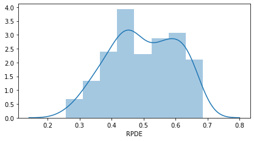

```
D2 is Symmetrically Skewed as Skewness = 0.43
```

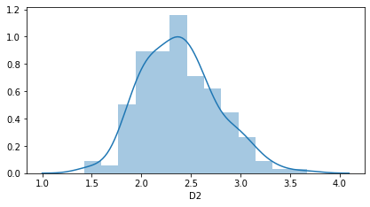

```python
n=1
pds2=pds[['RPDE','D2']]
for x in pds2:
    series          = pds2[x]
    skewness        = series.skew()
    if skewness > -.5  and skewness < .5 :
        print(x,"is Symmetrically Skewed as Skewness =",round(skewness,3),'\n')
    elif skewness > .25:
            print(x,"is Positively Skewed towards Right side of asymmetric distribution as Skewness =",round(skewness,3),'\n')
    elif skewness < -.25:
            print(x,"is Negatively Skewed towards Left side of asymmetric distribution as Skewness =",round(skewness,3),'\n')
    plt.figure(figsize= (15,20))
    plt.subplot(5,2,n)
    n=n+1
    sns.distplot(pds2[x])
    plt.xlabel(x)
    plt.show()
```

```
DFA is Symmetrically Skewed as Skewness = -0.033
```

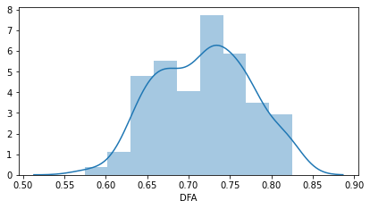

```python
n=1
pds2=pds[['DFA']]
for x in pds2:
    series          = pds2[x]
    skewness        = series.skew()
    if skewness > -.5  and skewness < .5 :
        print(x,"is Symmetrically Skewed as Skewness =",round(skewness,3),'\n')
    elif skewness > .25:
            print(x,"is Positively Skewed towards Right side of asymmetric distribution as Skewness =",round(skewness,3),'\n')
    elif skewness < -.25:
            print(x,"is Negatively Skewed towards Left side of asymmetric distribution as Skewness =",round(skewness,3),'\n')
    plt.figure(figsize= (15,20))
    plt.subplot(5,2,n)
    n=n+1
    sns.distplot(pds2[x])
    plt.xlabel(x)
    plt.show()
```

```
spread1 is Symmetrically Skewed as Skewness = 0.432
```

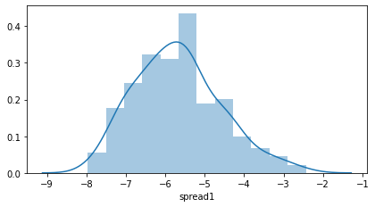

```
spread2 is Symmetrically Skewed as Skewness = 0.144
```

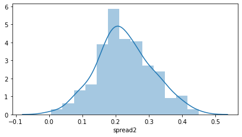

```
PPE is Positively Skewed towards Right side of asymmetric distribution as Skewness = 0.797
```

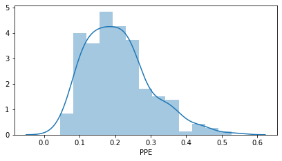

```python
n=1
pds2=pds[['spread1','spread2','PPE']]
for x in pds2:
    series          = pds2[x]
    skewness        = series.skew()
    if skewness > -.5  and skewness < .5 :
        print(x,"is Symmetrically Skewed as Skewness =",round(skewness,3),'\n')
    elif skewness > .25:
            print(x,"is Positively Skewed towards Right side of asymmetric distribution as Skewness =",round(skewness,3),'\n')
    elif skewness < -.25:
            print(x,"is Negatively Skewed towards Left side of asymmetric distribution as Skewness =",round(skewness,3),'\n')
    plt.figure(figsize= (15,20))
    plt.subplot(5,2,n)
    n=n+1
    sns.distplot(pds2[x])
    plt.xlabel(x)
    plt.show()
```

```python
#MDVP:Fo(Hz)	MDVP:Fhi(Hz)	MDVP:Flo(Hz)	MDVP:Jitter(%)	MDVP:Jitter(Abs)	MDVP:RAP	MDVP:PPQ	Jitter:DDP	MDVP:Shimmer	MDVP:Shimmer(dB)	...	Shimmer:DDA	NHR	HNR	RPDE	DFA	spread1	spread2	D2	PPE	status
```

```python
pdt=pds1

for x in pdt:
    pds[x]=pds[x].astype(float)
    att = pds[x]
    #main
    a = att.lt(0).sum()
    outlier = []
    outliervalue = []
    if a != 0:
        print(x,'has Negative Value of',a)
```

```
spread1 has Negative Value of 195
```

# Bivariate Analysis

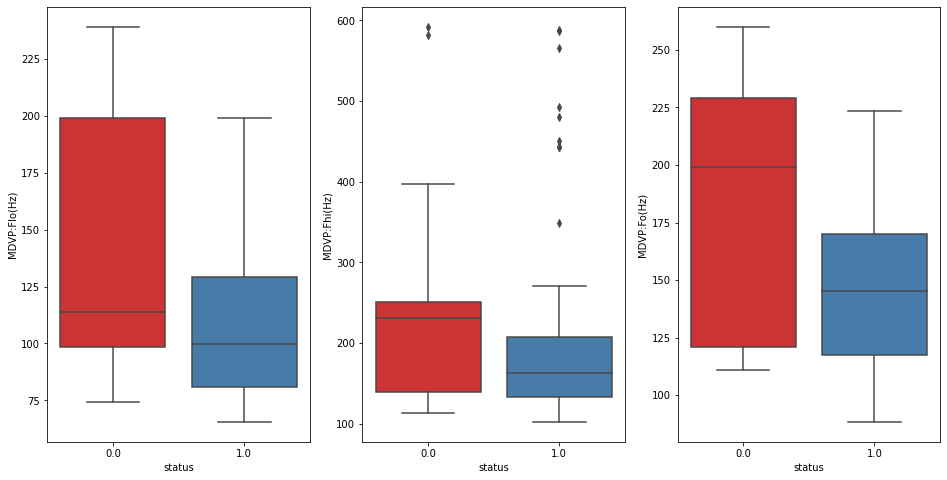

```python
fig, ax = plt.subplots(1,3,figsize=(16,8))
sns.boxplot(x='status',y='MDVP:Flo(Hz)',data=pds1,palette="Set1",ax=ax[0])
sns.boxplot(x='status',y='MDVP:Fhi(Hz)',data=pds1,palette="Set1",ax=ax[1])
sns.boxplot(x='status',y='MDVP:Fo(Hz)',data=pds1,palette="Set1",ax=ax[2])
```

When we look the relationship between status and MDVP:Fo(Hz) we can see the median value is around 199 Hz for people who are normal. For people who are affected with Parkinsons the median value comes around 145 Hz

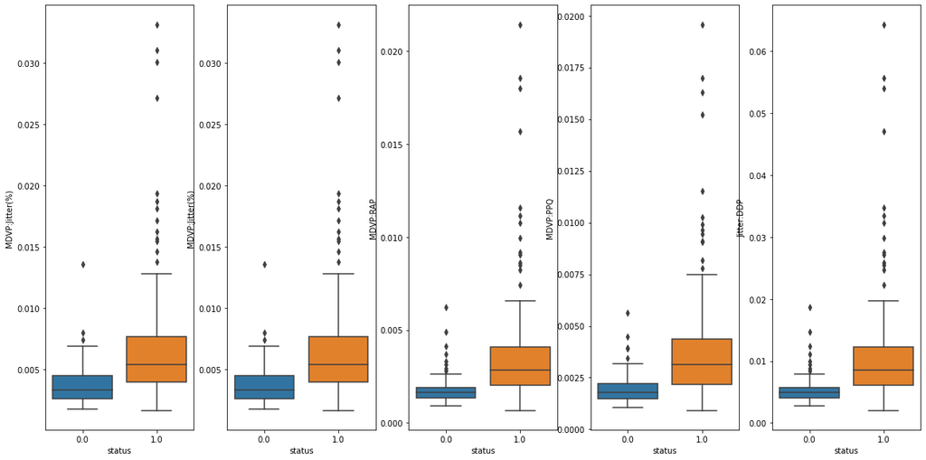

```python
# For categorical predictors
cols = ["MDVP:Jitter(%)","MDVP:Jitter(%)","MDVP:RAP","MDVP:PPQ","Jitter:DDP"]
fig, axs = plt.subplots(ncols = 5,figsize=(16,8))
fig.tight_layout()
for i in range(0,len(cols)):
    sns.boxplot(x='status',y=cols[i],data=pds1, ax = axs[i])
```

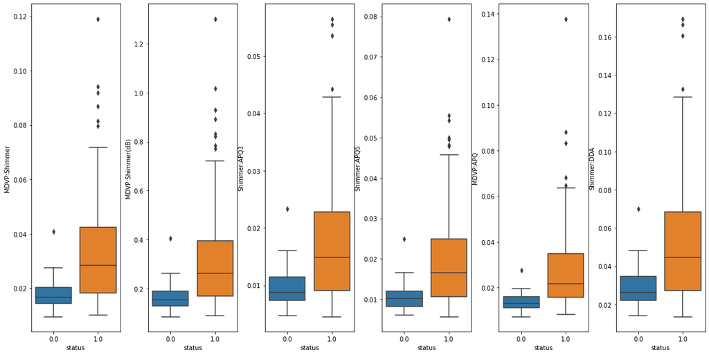

```python
# For categorical predictors
cols = ['MDVP:Shimmer','MDVP:Shimmer(dB)','Shimmer:APQ3','Shimmer:APQ5','MDVP:APQ','Shimmer:DDA']
fig, axs = plt.subplots(ncols = 6,figsize=(16,8))
fig.tight_layout()
for i in range(0,len(cols)):
    sns.boxplot(x='status',y=cols[i],data=pds1, ax = axs[i])
```

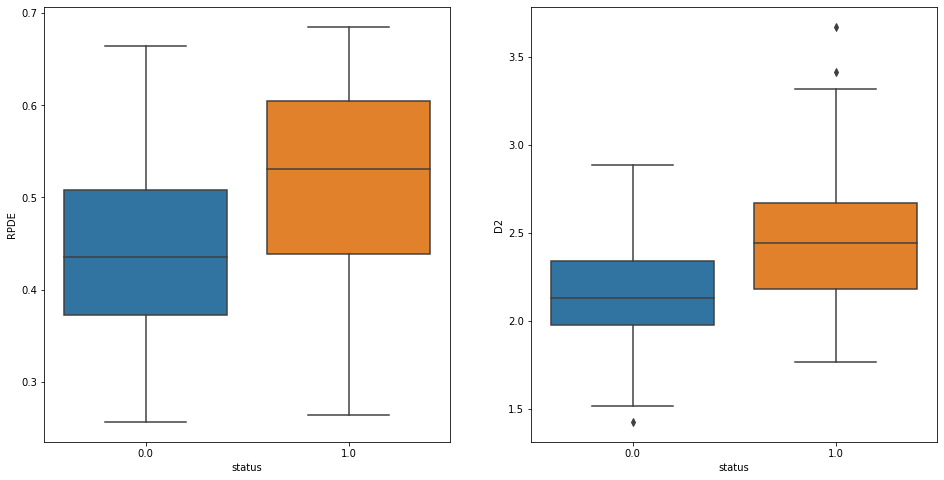

```python
fig, ax = plt.subplots(1,2,figsize=(16,8))
sns.boxplot(x='status',y='RPDE',data=pds1,ax=ax[0])
sns.boxplot(x='status',y='D2',data=pds1,ax=ax[1])
```

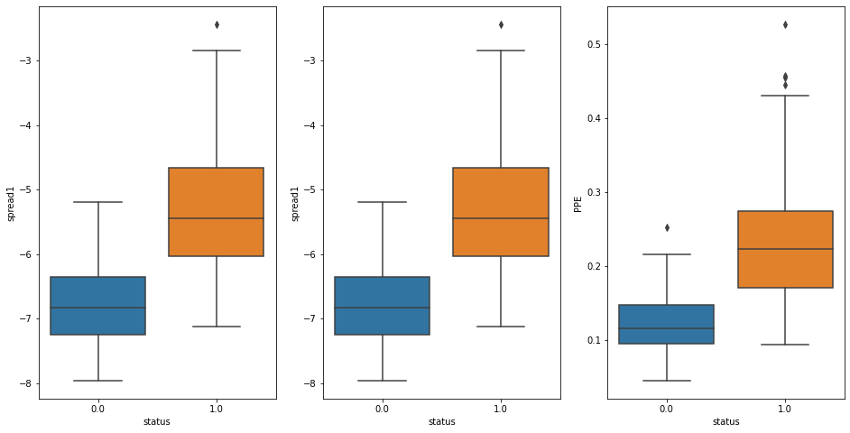

```python
fig, ax = plt.subplots(1,3,figsize=(16,8))
sns.boxplot(x='status',y='spread1',data=pds1,ax=ax[0])
sns.boxplot(x='status',y='spread1',data=pds1,ax=ax[1])
sns.boxplot(x='status',y='PPE',data=pds1,ax=ax[2])
```

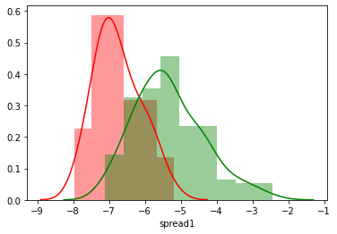

```python
sns.distplot( pds1[pds1.status == 0]['spread1'], color = 'r')
sns.distplot( pds1[pds1.status == 1]['spread1'], color = 'g')
```

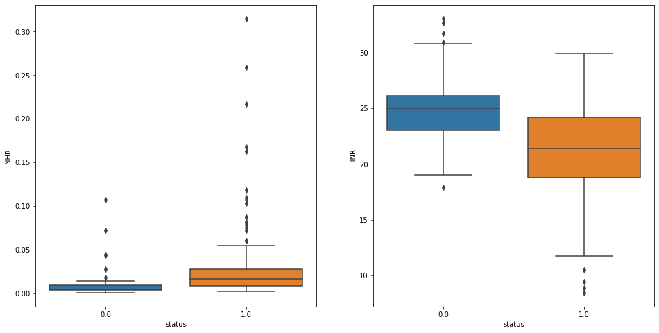

```python
fig, ax = plt.subplots(1,2,figsize=(16,8))
sns.boxplot(x='status',y='NHR',data=pds1,ax=ax[0])
sns.boxplot(x='status',y='HNR',data=pds1,ax=ax[1])
```

People who have PD(status equal to one) have higher levels of Noise to Harmonic ratio. Also, looking into the HNR ratio people who have PD have lower levels in the same.

**Distribution of the target column.**

```
Distribution of status column
```

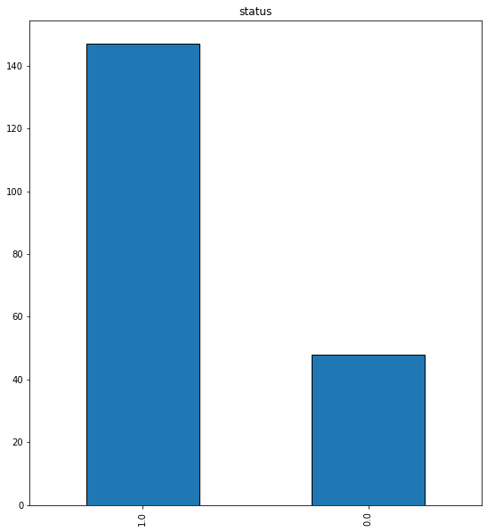

```python
# Set up a grid of plots
fig = plt.figure(figsize=(20,10))
fig_dims = (1, 2)

print('Distribution of status column')
plt.subplot2grid(fig_dims, (0,0))
pds1['status'].value_counts().plot(kind='bar', title='status',edgecolor="0")
```

```python
count_no_sub = len(pds1[pds1['status']==0])
print('Total Count of person who are healthy',count_no_sub)
count_sub = len(pds1[pds1['status']==1])
print("Total Count of person having parkinson's disease:",count_sub)
pct_of_no_sub = count_no_sub/(count_no_sub+count_sub)
print("Percentage of person who are healthy:", pct_of_no_sub*100)
pct_of_sub = count_sub/(count_no_sub+count_sub)
print("Percentage of  person having parkinson's disease:", pct_of_sub*100)
```

```
Total Count of person who are healthy 48
Total Count of person having parkinson's disease: 147
Percentage of person who are healthy: 24.615384615384617
Percentage of  person having parkinson's disease: 75.38461538461539
```

```python
pds1.groupby(pds1['status']).mean()
```

| status | MDVP:Fo(Hz) | MDVP:Fhi(Hz) | MDVP:Flo(Hz) | MDVP:Jitter(%) | MDVP:Jitter(Abs) | MDVP:RAP | MDVP:PPQ | Jitter:DDP | MDVP:Shimmer | MDVP:Shimmer(dB) | ... | MDVP:APQ | Shimmer:DDA | NHR | HNR | RPDE | DFA | spread1 | spread2 | D2 | PPE |
| --- | --- | --- | --- | --- | --- | --- | --- | --- | --- | --- | --- | --- | --- | --- | --- | --- | --- | --- | --- | --- | --- |
| 0.0 | 181.937771 | 223.636750 | 145.207292 | 0.003866 | 0.000023 | 0.001925 | 0.002056 | 0.005776 | 0.017615 | 0.162958 | ... | 0.013305 | 0.028511 | 0.011483 | 24.678750 | 0.442552 | 0.695716 | -6.759264 | 0.160292 | 2.154491 | 0.123017 |
| 1.0 | 145.180762 | 188.441463 | 106.893558 | 0.006989 | 0.000051 | 0.003757 | 0.003900 | 0.011273 | 0.033658 | 0.321204 | ... | 0.027600 | 0.053027 | 0.029211 | 20.974048 | 0.516816 | 0.725408 | -5.333420 | 0.248133 | 2.456058 | 0.233828 |

2 rows × 22 columns

# Split the dataset into training and test set in the ratio of 70:30 (Training:Test)

```python
pds1.columns
```

```
Index(['MDVP:Fo(Hz)', 'MDVP:Fhi(Hz)', 'MDVP:Flo(Hz)', 'MDVP:Jitter(%)',
       'MDVP:Jitter(Abs)', 'MDVP:RAP', 'MDVP:PPQ', 'Jitter:DDP',
       'MDVP:Shimmer', 'MDVP:Shimmer(dB)', 'Shimmer:APQ3', 'Shimmer:APQ5',
       'MDVP:APQ', 'Shimmer:DDA', 'NHR', 'HNR', 'RPDE', 'DFA', 'spread1',
       'spread2', 'D2', 'PPE', 'status'],
      dtype='object')
```

```python
pds = pds.drop('name',axis=1)
y=pds["status"]
bpx=pds.drop(['status'],axis=1)
x=bpx
accuracies={}
```

```python
#Standardizing and Normalizing data
standardized_X = preprocessing.scale(x)
normalized_X = preprocessing.normalize(x)
```

```python
scaler=MinMaxScaler((-1,1))
X=scaler.fit_transform(x)
Y=y
```

```python
x_train, x_test, y_train,  y_test = train_test_split(x, y,train_size=0.7, test_size=0.3,random_state=22)
X_train, X_test, Y_train,  Y_test = train_test_split(X, Y,train_size=0.7, test_size=0.3,random_state=22)

print(len(x_train)),print(len(x_test))
```

```
136
59
```

```
(None, None)
```

```python
x_train
```

|  | MDVP:Fo(Hz) | MDVP:Fhi(Hz) | MDVP:Flo(Hz) | MDVP:Jitter(%) | MDVP:Jitter(Abs) | MDVP:RAP | MDVP:PPQ | Jitter:DDP | MDVP:Shimmer | MDVP:Shimmer(dB) | ... | MDVP:APQ | Shimmer:DDA | NHR | HNR | RPDE | DFA | spread1 | spread2 | D2 | PPE |
| --- | --- | --- | --- | --- | --- | --- | --- | --- | --- | --- | --- | --- | --- | --- | --- | --- | --- | --- | --- | --- | --- |
| 160 | 114.238 | 124.393 | 77.022 | 0.00581 | 0.000050 | 0.00299 | 0.00316 | 0.00896 | 0.04009 | 0.406 | ... | 0.04114 | 0.04736 | 0.02073 | 20.437 | 0.653139 | 0.694571 | -5.185987 | 0.259229 | 2.151121 | 0.244948 |
| 140 | 170.368 | 268.796 | 79.543 | 0.00571 | 0.000030 | 0.00232 | 0.00269 | 0.00696 | 0.03273 | 0.281 | ... | 0.02824 | 0.05139 | 0.02485 | 18.540 | 0.677131 | 0.685057 | -4.796845 | 0.397749 | 2.963799 | 0.277227 |
| 178 | 148.790 | 158.359 | 138.990 | 0.00309 | 0.000020 | 0.00152 | 0.00186 | 0.00456 | 0.01574 | 0.142 | ... | 0.01309 | 0.02518 | 0.00488 | 24.412 | 0.402591 | 0.762508 | -6.311987 | 0.182459 | 2.251553 | 0.160306 |
| 175 | 115.380 | 123.109 | 108.634 | 0.00332 | 0.000030 | 0.00160 | 0.00199 | 0.00480 | 0.01503 | 0.137 | ... | 0.01133 | 0.02436 | 0.00401 | 26.005 | 0.405991 | 0.761255 | -5.966779 | 0.197938 | 1.974857 | 0.184067 |
| 153 | 121.345 | 139.644 | 98.250 | 0.00684 | 0.000060 | 0.00388 | 0.00332 | 0.01164 | 0.02534 | 0.241 | ... | 0.02056 | 0.04019 | 0.04179 | 21.520 | 0.566867 | 0.670475 | -4.865194 | 0.246404 | 2.013530 | 0.168581 |
| ... | ... | ... | ... | ... | ... | ... | ... | ... | ... | ... | ... | ... | ... | ... | ... | ... | ... | ... | ... | ... | ... |
| 102 | 139.224 | 586.567 | 66.157 | 0.03011 | 0.000220 | 0.01854 | 0.01628 | 0.05563 | 0.09419 | 0.930 | ... | 0.06023 | 0.16654 | 0.25930 | 10.489 | 0.596362 | 0.641418 | -3.269487 | 0.270641 | 2.690917 | 0.444774 |
| 100 | 125.641 | 141.068 | 116.346 | 0.03316 | 0.000260 | 0.02144 | 0.01522 | 0.06433 | 0.09178 | 0.891 | ... | 0.06196 | 0.16074 | 0.31482 | 8.867 | 0.671299 | 0.656846 | -3.700544 | 0.260481 | 2.991063 | 0.370961 |
| 44 | 243.439 | 250.912 | 232.435 | 0.00210 | 0.000009 | 0.00109 | 0.00137 | 0.00327 | 0.01419 | 0.126 | ... | 0.01033 | 0.02330 | 0.00454 | 25.368 | 0.438296 | 0.635285 | -7.057869 | 0.091608 | 2.330716 | 0.091470 |
| 132 | 119.056 | 125.213 | 86.795 | 0.00346 | 0.000030 | 0.00169 | 0.00170 | 0.00508 | 0.01201 | 0.106 | ... | 0.00915 | 0.01898 | 0.00903 | 23.389 | 0.470972 | 0.721308 | -5.436135 | 0.254909 | 2.516320 | 0.232209 |
| 117 | 170.756 | 450.247 | 79.032 | 0.00555 | 0.000030 | 0.00244 | 0.00261 | 0.00731 | 0.01725 | 0.175 | ... | 0.01652 | 0.02270 | 0.01802 | 25.690 | 0.486738 | 0.676023 | -4.597834 | 0.372114 | 2.975889 | 0.282780 |

136 rows × 22 columns

## Classification algorithm - 1. Logistic Regression

```python
# import logistic regression and train on tarining set
model = LogisticRegression()
model.fit(X_train, Y_train)
```

```
LogisticRegression()
```

```python
# Predict target column of test data
Y_pred = model.predict(X_test)
```

```python
accuracy = metrics.accuracy_score(Y_test, Y_pred)
print("Accuracy rate of",accuracy)
```

```
Accuracy rate of 0.8305084745762712
```

```python
print('Compute report precision    recall  F-measure  support\n',classification_report(Y_test, Y_pred))
```

```
Compute report precision    recall  F-measure  support
               precision    recall  f1-score   support

         0.0       0.89      0.47      0.62        17
         1.0       0.82      0.98      0.89        42

    accuracy                           0.83        59
   macro avg       0.85      0.72      0.75        59
weighted avg       0.84      0.83      0.81        59
```

```python
print("The Precision of Logistic Regression:",metrics.precision_score(Y_test, Y_pred))
```

```
The Precision of Logistic Regression: 0.82
```

```python
lr = metrics.confusion_matrix(Y_test, Y_pred)
lr
```

```
array([[ 8,  9],
       [ 1, 41]], dtype=int64)
```

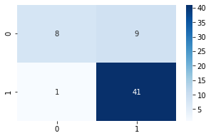

```python
# Display confusion matrix
cm= confusion_matrix(Y_test, Y_pred)
plt.figure(figsize = (5,3))
sns.heatmap(cm, annot=True,cmap='Blues', fmt='g')
```

## Classification algorithm - 2. K-NN

```python
# Creating odd list of K for KNN
myList = list(range(1,20))

# Subsetting just the odd ones
neighbors = list(filter(lambda x: x % 2 != 0, myList))
```

```python
# Empty list that will hold accuracy scores
ac_scores = []

# Perform accuracy metrics for values from 1,3,5....19
for k in neighbors:
    knn = KNeighborsClassifier(n_neighbors=k)
    knn.fit(x_train, y_train)

    # Predict the response
    y_Pred = knn.predict(x_test)

    # Evaluate accuracy
    scores = accuracy_score(y_test, y_Pred)
    ac_scores.append(scores)

# Changing to misclassification error
MSE = [1 - x for x in ac_scores]

# Determining best k
optimal_k = neighbors[MSE.index(min(MSE))]
print("The optimal number of neighbors is %d" % optimal_k)
```

```
The optimal number of neighbors is 9
```

```python
# Build kNN Model
NNH = KNeighborsClassifier(n_neighbors= optimal_k , weights = 'distance' )
# Call Nearest Neighbour algorithm
NNH.fit(x_train, y_train)
```

```
KNeighborsClassifier(n_neighbors=9, weights='distance')
```

```python
# Predict target column of test data
predicted_labels = NNH.predict(x_test)
y_pred = NNH.predict(x_test)
```

```python
accuracy = metrics.accuracy_score(y_test,predicted_labels)
print("Accuracy rate of KNN",accuracy)
```

```
Accuracy rate of KNN 0.864406779661017
```

```python
print("The Precision of KNN :",metrics.precision_score(y_test, y_pred))
```

```
The Precision of KNN : 0.8541666666666666
```

```python
print('Compute report precision    recall  F-measure  support\n',classification_report(y_test, y_pred))
```

```
Compute report precision    recall  F-measure  support
               precision    recall  f1-score   support

         0.0       0.91      0.59      0.71        17
         1.0       0.85      0.98      0.91        42

    accuracy                           0.86        59
   macro avg       0.88      0.78      0.81        59
weighted avg       0.87      0.86      0.85        59
```

```python
knn = confusion_matrix(y_test, y_pred)
knn
```

```
array([[10,  7],
       [ 1, 41]], dtype=int64)
```

```
Confusion Matrix
```

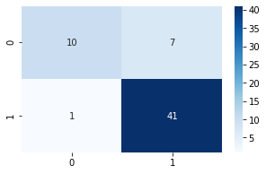

```python
# calculate accuracy measures and confusion matrix
print("Confusion Matrix")
cm=metrics.confusion_matrix(y_test, predicted_labels)

# Display confusion matrix
plt.figure(figsize = (5,3))
sns.heatmap(cm, annot=True,cmap='Blues', fmt='g')
```

## Classification algorithm - 3. Naïve Bayes

```python
#Create a Gaussian Classifier
gnb = GaussianNB()

#Train the model using the training sets
gnb.fit(x_train, y_train)
```

```
GaussianNB()
```

```python
#Predict the response for test dataset
y_pred = gnb.predict(x_test)
```

```python
accuracy = metrics.accuracy_score(y_test, y_pred)
print("Accuracy of Navie:",accuracy)
```

```
Accuracy of Navie: 0.6610169491525424
```

```python
print('Compute report precision    recall  F-measure  support\n',classification_report(y_test, y_pred))
```

```
Compute report precision    recall  F-measure  support
               precision    recall  f1-score   support

         0.0       0.45      0.82      0.58        17
         1.0       0.89      0.60      0.71        42

    accuracy                           0.66        59
   macro avg       0.67      0.71      0.65        59
weighted avg       0.77      0.66      0.68        59
```

```python
print("The Precision of Navie Bayes :",metrics.precision_score(y_test, y_pred))
```

```
The Precision of Navie Bayes : 0.8928571428571429
```

```python
nb = confusion_matrix(y_test, y_pred)
nb
```

```
array([[14,  3],
       [17, 25]], dtype=int64)
```

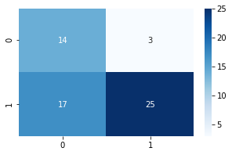

```python
cm = confusion_matrix(y_test, y_pred)
plt.figure(figsize = (5,3))
sns.heatmap(cm, annot=True,cmap='Blues', fmt='g')
```

## Classification algorithm - 4. SVM

```python
svm =svm.SVC(gamma=0.025, C=3)
#svm.fit(trainingData, b_train)
#svm.score(testData, b_test)
svm.fit(x_train, y_train)
svm.score(x_test, y_test)

y_pred = svm.predict(x_test)
accuracy = (metrics.accuracy_score(y_test, y_pred))
print('Support Vector Machines accuracy: ', accuracy)
print('Confusion Matrix: ')
print(metrics.confusion_matrix(y_test, y_pred))
```

```
Support Vector Machines accuracy:  0.7457627118644068
Confusion Matrix:
[[ 5 12]
 [ 3 39]]
```

# Training a meta-classifier

```python
clf1 = KNeighborsClassifier(n_neighbors=1)
clf2 = svm
clf3 = GaussianNB()
lr = LogisticRegression()
sclf = StackingClassifier(classifiers=[clf1, clf2, clf3],
                          meta_classifier=lr)

print('3-fold cross validation:\n')

for clf, label in zip([clf1, clf2, clf3, sclf],
                      ['KNN',
                       'SVM',
                       'Naive Bayes',
                       'Meta-classifier']):

    scores = model_selection.cross_val_score(clf, x, y,
                                              cv=3, scoring='accuracy')
    print("Accuracies of ",label,'are ',scores,"with  mean= %0.2f and std= (+/- %0.2f)" % (scores.mean(), scores.std()),'\n')
```

```
3-fold cross validation:

Accuracies of  KNN are  [0.75384615 0.76923077 0.76923077] with  mean= 0.76 and std= (+/- 0.01)

Accuracies of  SVM are  [0.73846154 0.72307692 0.76923077] with  mean= 0.74 and std= (+/- 0.02)

Accuracies of  Naive Bayes are  [0.69230769 0.69230769 0.66153846] with  mean= 0.68 and std= (+/- 0.01)

Accuracies of  Meta-classifier are  [0.75384615 0.75384615 0.76923077] with  mean= 0.76 and std= (+/- 0.01)
```

# Standard Ensemble model

## Build Decision Tree Model

```python
dt = DecisionTreeClassifier(criterion='gini',random_state=69)
```

```python
dt.fit(x_train, y_train)
```

```
DecisionTreeClassifier(random_state=69)
```

```python
print(dt.score(x_train, y_train))

dt.score(x_test , y_test)
```

```
1.0
```

```
0.8305084745762712
```

```python
y_pred = dt.predict(x_test)
```

```python
confusion_matrix(y_test,y_pred)
```

```
array([[13,  4],
       [ 6, 36]], dtype=int64)
```

```python
accuracy = accuracy_score(y_test, y_pred)
accuracies['Decision Tree'] = accuracy
accuracy
```

```
0.8305084745762712
```

```
0.8305084745762712
```

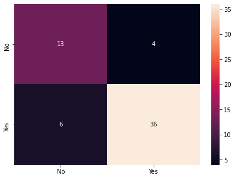

```python
print(dt.score(x_test , y_test))
y_predict = dt.predict(x_test)

cm=metrics.confusion_matrix(y_test, y_predict, labels=[0, 1])

df_cm = pd.DataFrame(cm, index = [i for i in ["No","Yes"]],
                  columns = [i for i in ["No","Yes"]])
plt.figure(figsize = (7,5))
sns.heatmap(df_cm, annot=True ,fmt='g')
```

**Count mis-classified one**

```python
count_misclassified = (y_test != y_pred).sum()
print('Misclassified samples: {}'.format(count_misclassified))
```

```
Misclassified samples: 10
```

#### Visualizing the Decision Tree

```python
train_char_label = ['No', 'Yes']
pd_tree_regularized = open('pd_tree_regularized.dot','w')
dot_data = tree.export_graphviz(dt, out_file= pd_tree_regularized , feature_names = list(x_train), class_names = list(train_char_label))

pd_tree_regularized.close()

print (pd.DataFrame(dt.feature_importances_, columns = ["Imp"], index = x_train.columns))
```

```
                       Imp
MDVP:Fo(Hz)       0.000000
MDVP:Fhi(Hz)      0.055852
MDVP:Flo(Hz)      0.000000
MDVP:Jitter(%)    0.000000
MDVP:Jitter(Abs)  0.000000
MDVP:RAP          0.000000
MDVP:PPQ          0.000000
Jitter:DDP        0.000000
MDVP:Shimmer      0.000000
MDVP:Shimmer(dB)  0.000000
Shimmer:APQ3      0.000000
Shimmer:APQ5      0.071626
MDVP:APQ          0.000000
Shimmer:DDA       0.009874
NHR               0.055709
HNR               0.192898
RPDE              0.041749
DFA               0.000000
spread1           0.000000
spread2           0.000000
D2                0.039693
PPE               0.532599
```

```python
retCode = system("dot -Tpng credit_tree.dot -o credit_tree.png")

#Works only if "dot" command works on you machine

retCode = system("dot -Tpng credit_tree.dot -o credit_tree.png")
if(retCode>0):
    print("system command returning error: "+str(retCode))
else:
    display(Image("pd_tree_regularized.png"))
```

```
system command returning error: 1
```

**Reducing over fitting (Regularization)**

```python
dtR = DecisionTreeClassifier(criterion = 'gini', max_depth = 3, random_state=1)
dtR.fit(x_train, y_train)
print(dtR.score(x_train, y_train))
print(dtR.score(x_test, y_test))
```

```
0.9558823529411765
0.8135593220338984
```

```python
train_char_label = ['No', 'Yes']
pd_tree_regularized = open('pd_tree_regularized.dot','w')
dot_data = tree.export_graphviz(dtR, out_file= pd_tree_regularized , feature_names = list(x_train), class_names = list(train_char_label))

pd_tree_regularized.close()

#Works only if "dot" command works on you machine
retCode = system("dot -Tpng credit_tree.dot -o credit_tree.png")
if(retCode>0):
    print("system command returning error: "+str(retCode))
else:
    display(Image("pd_tree_regularized.png"))
```

```
system command returning error: 1
```

```python
print (pd.DataFrame(dtR.feature_importances_, columns = ["Imp"], index = x_train.columns))
```

```
                       Imp
MDVP:Fo(Hz)       0.000000
MDVP:Fhi(Hz)      0.069908
MDVP:Flo(Hz)      0.000000
MDVP:Jitter(%)    0.000000
MDVP:Jitter(Abs)  0.000000
MDVP:RAP          0.000000
MDVP:PPQ          0.000000
Jitter:DDP        0.000000
MDVP:Shimmer      0.000000
MDVP:Shimmer(dB)  0.012359
Shimmer:APQ3      0.000000
Shimmer:APQ5      0.000000
MDVP:APQ          0.000000
Shimmer:DDA       0.000000
NHR               0.000000
HNR               0.149156
RPDE              0.052256
DFA               0.000000
spread1           0.000000
spread2           0.000000
D2                0.049682
PPE               0.666638
```

```python
y_pred = dtR.predict(x_test)
```

```python
accuracy = accuracy_score(y_test, y_pred)
accuracies['Decision Tree(reduced)'] = accuracy
accuracy
```

```
0.8135593220338984
```

```python
confusion_matrix(y_test,y_pred)
```

```
array([[13,  4],
       [ 7, 35]], dtype=int64)
```

```
0.8135593220338984
```

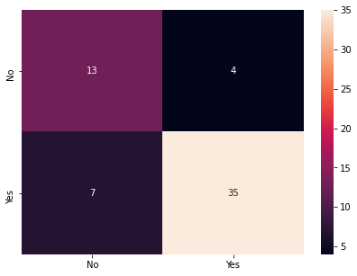

```python
print(dtR.score(x_test , y_test))

cm=metrics.confusion_matrix(y_test, y_pred, labels=[0, 1])

df_cm = pd.DataFrame(cm, index = [i for i in ["No","Yes"]],
                  columns = [i for i in ["No","Yes"]])
plt.figure(figsize = (7,5))
sns.heatmap(df_cm, annot=True ,fmt='g')
```

## Standard Ensemble model - 1. Bagging

```python
from sklearn.ensemble import BaggingClassifier

bgcl = BaggingClassifier(base_estimator=dt, n_estimators=50,random_state=1)
#bgcl = BaggingClassifier(n_estimators=50,random_state=1)

bgcl = bgcl.fit(x_train, y_train)
```

```python
y_pred = bgcl.predict(x_test)
accuracy = accuracy_score(y_test, y_pred)
accuracies['Bagging'] = accuracy
accuracy
```

```
0.8813559322033898
```

```python
print('Compute report precision    recall  F-measure  support\n',classification_report(y_test, y_pred))
```

```
Compute report precision    recall  F-measure  support
               precision    recall  f1-score   support

         0.0       0.81      0.76      0.79        17
         1.0       0.91      0.93      0.92        42

    accuracy                           0.88        59
   macro avg       0.86      0.85      0.85        59
weighted avg       0.88      0.88      0.88        59
```

```python
confusion_matrix(y_test,y_pred)
```

```
array([[13,  4],
       [ 3, 39]], dtype=int64)
```

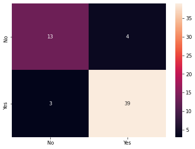

```python
cm=metrics.confusion_matrix(y_test, y_pred,labels=[0, 1])

df_cm = pd.DataFrame(cm, index = [i for i in ["No","Yes"]],
                  columns = [i for i in ["No","Yes"]])
plt.figure(figsize = (7,5))
sns.heatmap(df_cm, annot=True ,fmt='g')
```

```python
count_misclassified = (y_test != y_pred).sum()
print('Misclassified samples in Bagging: {}'.format(count_misclassified))
```

```
Misclassified samples in Bagging: 7
```

## Standard Ensemble model - 2. AdaBoosting

```python
from sklearn.ensemble import AdaBoostClassifier
abcl = AdaBoostClassifier(n_estimators=10, random_state=1)
#abcl = AdaBoostClassifier( n_estimators=50,random_state=1)
abcl = abcl.fit(x_train, y_train)
```

```python
y_pred = abcl.predict(x_test)
accuracy = accuracy_score(y_test, y_pred)
accuracies['AdaBoosting'] = accuracy
accuracy
```

```
0.7796610169491526
```

```python
print('Compute report precision    recall  F-measure  support\n',classification_report(y_test, y_pred))
```

```
Compute report precision    recall  F-measure  support
               precision    recall  f1-score   support

         0.0       0.61      0.65      0.63        17
         1.0       0.85      0.83      0.84        42

    accuracy                           0.78        59
   macro avg       0.73      0.74      0.74        59
weighted avg       0.78      0.78      0.78        59
```

```python
confusion_matrix(y_test,y_pred)
```

```
array([[11,  6],
       [ 7, 35]], dtype=int64)
```

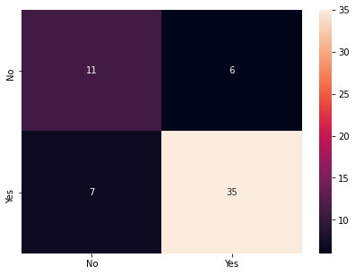

```python
cm=metrics.confusion_matrix(y_test, y_pred,labels=[0, 1])

df_cm = pd.DataFrame(cm, index = [i for i in ["No","Yes"]],
                  columns = [i for i in ["No","Yes"]])
plt.figure(figsize = (7,5))
sns.heatmap(df_cm, annot=True ,fmt='g')
```

```python
count_misclassified = (y_test != y_pred).sum()
print('Misclassified samples in Ada Boosting: {}'.format(count_misclassified))
```

```
Misclassified samples in Ada Boosting: 13
```

## Standard Ensemble model - 3. GradientBoost

```python
from sklearn.ensemble import GradientBoostingClassifier
gbcl = GradientBoostingClassifier(n_estimators = 50,random_state=1)
gbcl = gbcl.fit(x_train, y_train)
```

```python
y_pred = gbcl.predict(x_test)
accuracy = accuracy_score(y_test, y_pred)
accuracies['GradientBoost'] = accuracy
accuracy
```

```
0.8983050847457628
```

```python
print('Compute report precision    recall  F-measure  support\n',classification_report(y_test, y_pred))
```

```
Compute report precision    recall  F-measure  support
               precision    recall  f1-score   support

         0.0       0.82      0.82      0.82        17
         1.0       0.93      0.93      0.93        42

    accuracy                           0.90        59
   macro avg       0.88      0.88      0.88        59
weighted avg       0.90      0.90      0.90        59
```

```python
confusion_matrix(y_test,y_pred)
```

```
array([[14,  3],
       [ 3, 39]], dtype=int64)
```

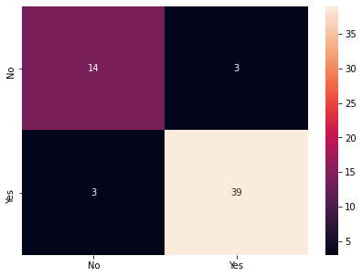

```python
cm=metrics.confusion_matrix(y_test, y_pred,labels=[0, 1])

df_cm = pd.DataFrame(cm, index = [i for i in ["No","Yes"]],
                  columns = [i for i in ["No","Yes"]])
plt.figure(figsize = (7,5))
sns.heatmap(df_cm, annot=True ,fmt='g')
```

```python
count_misclassified = (y_test != y_pred).sum()
print('Misclassified samples in Gradient Boosting: {}'.format(count_misclassified))
```

```
Misclassified samples in Gradient Boosting: 6
```